# Scottish Borders - Cancer Rates - Report

```r
library(tidyverse)
library(janitor)
library(plotly)
```

```r
hb_names <- read_csv("raw_data/geography_codes_and_labels_hb2014_01042019.csv") %>%
  clean_names() %>%
  select(hb, hb_name)
hb_incidence <- read_csv("raw_data/incidence_by_health_board.csv") %>%
  clean_names() %>%
  left_join(hb_names, "hb") %>%
  filter(hb_name == "NHS Borders") %>%
  select(-ends_with("_qf"))
```

# Total annual cancer incidences in the borders

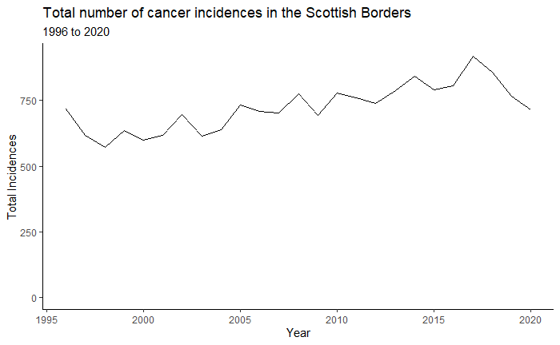

```r
hb_incidence %>%
  filter(cancer_site == "All cancer types" & sex == "All") %>%
  ggplot(aes(x = year, y = incidences_all_ages)) +
  geom_line() +
  theme_classic() +
  scale_y_continuous(limits = c(0,NA)) +
  labs(x = "Year",
       y = "Total Incidences",
       title = "Total number of cancer incidences in the Scottish Borders",
       subtitle = "1996 to 2020")
```

The year on year incidence rates of cancer has trended upwards since 1996 reaching a peak in 2017, since 2017, however, there has been a significant downwards trend with the incidences in 2020 being the lowest since 2009, albeit this is presumably due to the covid pandemic where people were advised not to go to hospitals except in emergencies and many cancers may have gone un-diagnosed during this time period.

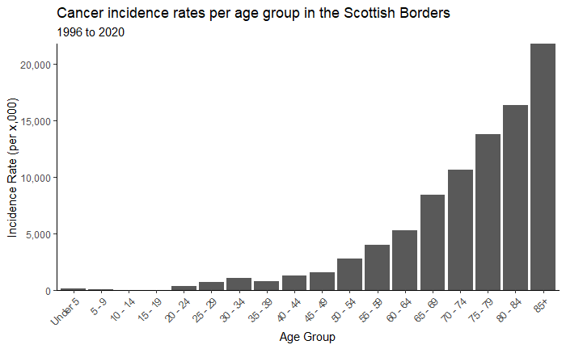

```r
hb_5yr_incidence_rates <- hb_5yr %>%
  filter(sex != "All") %>%
  mutate(sex = factor(sex, c("Male", "Female"))) %>%
  pivot_longer(incidence_rate_age_under5:incidence_rate_age85and_over,
               names_to = "age_group", values_to = "incidences") %>%
  select(id:sex, age_group, incidences) %>%
  mutate(age_group = str_remove(age_group, "incidence_rate_age|"),
         age_group = str_remove(age_group, "_"),
         age_group = str_replace(age_group, "to", " - "),
         age_group = str_replace(age_group, "under5", "Under 5"),
         age_group = str_replace(age_group, "85andover", "85+"))


age_group_list <- hb_5yr %>%
  filter(sex != "All") %>%
  mutate(sex = factor(sex, c("Male", "Female"))) %>%
  select(id:incidences_age85and_over) %>%
  pivot_longer(incidences_age_under5:incidences_age85and_over,
               names_to = "age_group", values_to = "incidences") %>%
  mutate(age_group = str_remove(age_group, "incidences_age|"),
         age_group = str_remove(age_group, "_"),
         age_group = str_replace(age_group, "to", " - "),
         age_group = str_replace(age_group, "under5", "Under 5"),
         age_group = str_replace(age_group, "85andover", "85+")) %>%
  head(18) %>%
  pull(age_group)

hb_5yr_incidence_rates %>%
  mutate(age_group = factor(age_group, levels = age_group_list)) %>%
  ggplot(aes(x = age_group, y = incidences)) +
  geom_col() +
  scale_y_continuous(expand = c(0, 0), labels = scales::comma) +
  theme_classic()+
  theme(legend.position = "none",
        axis.text.x = element_text(angle = 45, hjust = 1)) +
  labs(x = "Age Group",
       y = "Incidence Rate (per x,000)",
       title = "Cancer incidence rates per age group in the Scottish Borders",
       subtitle = "1996 to 2020")
```

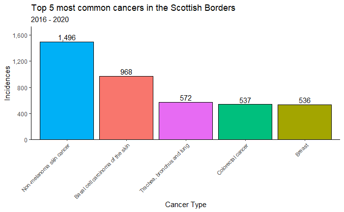

sex of top 5 cancers

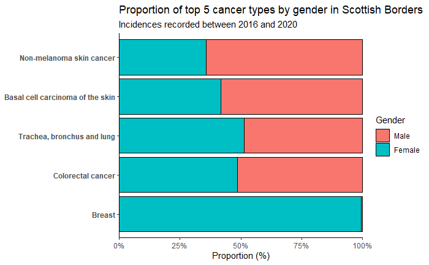

```r
top_5_list <- top_5_cancers_sex %>%
  pull(cancer_site)

hb_5yr %>%
  filter(cancer_site %in% top_5_list, sex != "All") %>%
  select(id:sex, incidences_all_ages) %>%
  mutate(sex = factor(sex, c("Male", "Female")),
         cancer_site = factor(cancer_site, levels = rev(top_5_cancers_list))) %>%
  ggplot(aes(x = cancer_site, y = incidences_all_ages, fill = sex)) +
  geom_col(position = "fill", col = "black") +
  scale_y_continuous(labels = scales::percent, expand = c(0, 0)) +
  labs(y = "Proportion (%)",
       title = "Proportion of top 5 cancer types by gender in Scottish Borders",
       subtitle = "Incidences recorded between 2016 and 2020",
       fill = "Gender") +
  theme_classic() +
  theme(axis.title.y = element_blank(),
        axis.text.y = element_text(face = "bold")) +
  coord_flip()
```

[output not shown]

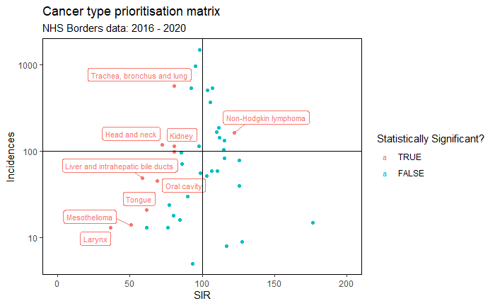

```r
library(ggrepel)

hb_5yr %>%
  select(cancer_site, sex, incidences_all_ages,
         standardised_incidence_ratio:sir_upper95pc_confidence_interval) %>%
  filter(sex == "All", incidences_all_ages > 0, cancer_site != "All cancer types") %>%
  mutate(standardised_incidence_ratio = round(standardised_incidence_ratio, 1),
         significant = if_else(sir_lower95pc_confidence_interval > 100 |
                                 sir_upper95pc_confidence_interval < 100,
                               TRUE,
                               FALSE),
         significant = factor(significant, levels = c("TRUE", "FALSE")),
         clabel = if_else(significant == TRUE, cancer_site, "")) %>%
  rename(SIR = standardised_incidence_ratio,
         Incidences = incidences_all_ages,
         Type = cancer_site) %>%
  ggplot(aes(y = Incidences, x = SIR, colour = significant,
             label = clabel)) +
  geom_point() +
  geom_label_repel(size = 3) +
  xlim(0,200) +
  ylim(0, 10000) +
  scale_y_continuous(trans = "log10") +
  theme_classic() +
  geom_vline(aes(xintercept = 100)) +
  geom_hline(aes(yintercept = 100)) +
  theme(panel.background = element_rect(colour = "black")) +
  labs(x = "SIR",
       y = "Incidences",
       title = "Cancer type prioritisation matrix",
       subtitle = "NHS Borders data: 2016 - 2020",
       colour = "Statistically Significant?")
```

The plot above shows how the standardised incidence rate (the ratio of the actual incidences in the region and the overall rate for the country multiplied by 100) changes across each cancer type with the number of incidences used as the scale on the y-axis. The purpose of this graph is to help identify which cancer types are either statistically significantly lower or higher between the Borders values and the national values to highlights any potential areas of improvement. The graph is interpreted as follows, SIR values greater than 100 indicate that there are higher rates of cancer in the borders compared with national rates and coversely, if this is lower than 100 then there are lower rates of cancer compared with the national rates. The graph is split into a further two sections indicating the number of incidences (i.e. the frequency of people with the cancer). Each quadrant takes into account whether the SIR is higher or lower than national levels or if the incidence frequency is higher or lower than 100.

The top-right quadrant indicates the cancer types which affect a lot of people and have higher rates than the national average (this is the quadrant which could indicate which cancer types to focus any public healthcare spend). The bottom-right quadrant shows higher rates but lower incidences, bottom-left shows both low rates and low frequency and top-left shows higher frequency and lower rates.